# DATA 602 - Bootstrapping within the Context of Regression

# Resampling for Correlation and Regression - the Bootstrap

In the bootstrap method, we re-sample $n$ bivariate data points $(x_{1}, y_{1}), (x_{2}, y_{2}), \cdots, (x_{n}, y_{n})$, from which various *bootstrap statistics*, such as

1. $r_{Boot}$
2. $a_{Boot}$
3. $b_{boot}$
4. $\mu_{y|x}$ for $x = 60000$

can be estimated.

## The Bootstrap and SAT Math Scores

Recall the SAT_2010 data:

```r
SAT_2010high = select(filter(SAT_2010, sat_percategory=="high"), state, math, salary) #filter out 'high' states and assign as a subset
SAT_2010high
```

| state | math | salary |
| --- | --- | --- |
| Connecticut | 514 | 67565 |
| Delaware | 495 | 59932 |
| Georgia | 490 | 55766 |
| Indiana | 505 | 52484 |
| Maine | 467 | 48410 |
| Maryland | 506 | 67167 |
| Massachusetts | 526 | 72734 |
| New Hampshire | 524 | 54013 |
| New Jersey | 514 | 68384 |
| New York | 499 | 75212 |

[output cut: 4 more lines]

There consists of $n = 14$ cases here, or 14 $(x,y)$ cases with respect to $y$ is the **math** data and $x$ is the **salary** data. In the bootstrap, we *resample* $n = 14$ bivariate data points, for each of which we compute the relevant statistic(s). This done many times over, say 1000 or 5000. This process ultimately will produce a *distribution* of the bootstrap statistic. We can then find percentiles, or cut-offs, which will then serve as a bootstrap confidence interval for the associated parameter.

Here is the process in obtaining the bootstrap statistics $r_{Boot}$, $a_{Boot}$, and $b_{Boot}$ from the **SAT_2010high** data frame.

**Step 1: Write some code!**

The code below, documented, demonstrates how to re-sample (or sample with replacement) $n = 14$ data points from the data above.

```r
Nbootstraps = 3000 #resample n =  14, 3000 times
cor.boot = numeric(Nbootstraps) #define a vector to be filled by the cor boot stat
a.boot = numeric(Nbootstraps) #define a vector to be filled by the a boot stat
b.boot = numeric(Nbootstraps) #define a vector to be filled by the b boot stat
ymean.boot = numeric(Nbootstraps) #define a vector to be filled by the predicted y boot stat
```

The above chunk is ran before we go any further, as we are setting up some “global” parameters for the code.

The code below is created to carry out the bootstrap:

```r
nsize = dim(SAT_2010high)[1]  #set the n to be equal to the number of bivariate cases, number of rows
xvalue = 60000 #set x = 60000
#start of the for loop
for(i in 1:Nbootstraps)
{   #start of the loop
    index = sample(nsize, replace=TRUE)  #randomly picks n- number between 1 and n, assigns as index
    SAT.boot = SAT_2010high[index, ] #accesses the i-th row of the SAT_2010High data frame
    #
    cor.boot[i] = cor(~salary, ~math, data=SAT.boot) #computes correlation for each bootstrap sample
    SAT.lm = lm(math~salary, data=SAT.boot)  #set up the linear model
    a.boot[i] = coef(SAT.lm)[1] #access the computed value of a, in position 1
    b.boot[i] = coef(SAT.lm)[2] #access the computed valeu of b, in position 2
    ymean.boot[i] = a.boot[i] + (b.boot[i]*xvalue)
}
#end the loop
#create a data frame that holds the results of teach of he Nbootstraps
    bootstrapresultsdf = data.frame(cor.boot, a.boot, b.boot, ymean.boot)
```

An inspection of these results

```r
head(bootstrapresultsdf, 3)
```

|  | cor.boot | a.boot | b.boot | ymean.boot |
| --- | --- | --- | --- | --- |
| 1 | -0.3857065 | 558.3517 | -0.0009697869 | 500.1645 |
| 2 | 0.6348283 | 412.8478 | 0.0013872009 | 496.0799 |
| 3 | 0.4889261 | 460.0946 | 0.0006595012 | 499.6647 |

```r
tail(bootstrapresultsdf, 3)
```

|  | cor.boot | a.boot | b.boot | ymean.boot |
| --- | --- | --- | --- | --- |
| 2998 | 0.7686467 | 401.8423 | 0.001666511 | 501.833 |
| 2999 | 0.6484895 | 429.1011 | 0.001145832 | 497.851 |
| 3000 | 0.7648311 | 390.3916 | 0.001872723 | 502.755 |

## 1. Bootstrap Distribution of $r_{boot}$

`ggplot` is invoked to examine the disribution of the 3000 computed values of $r_{boot}$:

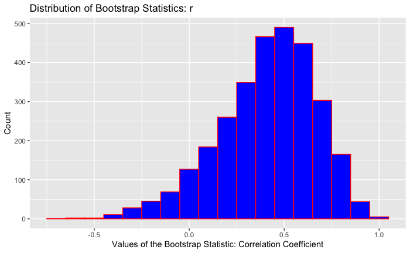

```r
bootstrapresultsdf %>%
  ggplot(aes(x = cor.boot)) +
  geom_histogram(col = "red", fill = "blue", binwidth = 0.1) +
  xlab("Values of the Bootstrap Statistic: Correlation Coefficient") +
  ylab("Count") +
  ggtitle("Distribution of Bootstrap Statistics: r")
```

We now use `favstats` to obtain the mean of the 3000 values of $r_{boot}$:

```r
favstats(~cor.boot, data = bootstrapresultsdf)
```

|  | min | Q1 | median | Q3 | max | mean | sd | n | missing |
| --- | --- | --- | --- | --- | --- | --- | --- | --- | --- |
|  | -0.6769597 | 0.2558024 | 0.4400022 | 0.5961957 | 0.9954586 | 0.4117729 | 0.2559019 | 3000 | 0 |

```r
favstats(~cor.boot, data = bootstrapresultsdf)
```

|  | min | Q1 | median | Q3 | max | mean | sd | n | missing |
| --- | --- | --- | --- | --- | --- | --- | --- | --- | --- |
|  | -0.6769597 | 0.2558024 | 0.4400022 | 0.5961957 | 0.9954586 | 0.4117729 | 0.2559019 | 3000 | 0 |

```r
qdata(~cor.boot, c(0.025, 0.975), data = bootstrapresultsdf)
```

|  | quantile | p |
| --- | --- | --- |
| 2.5% | -0.1812240 | 0.025 |
| 97.5% | 0.8258208 | 0.975 |

## 2. Bootstrap Disribution of $a_{boot}$

Similar to our steps in 1, the bootstrap distribution of $a_{boot}$ is provided below

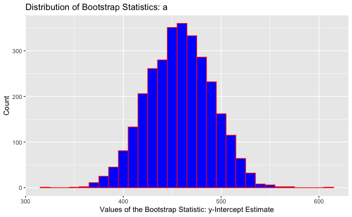

```r
bootstrapresultsdf %>%
  ggplot(aes(x = a.boot)) +
  geom_histogram(col = "red", fill = "blue", binwidth = 10) +
  xlab("Values of the Bootstrap Statistic: y-Intercept Estimate") +
  ylab("Count") +
  ggtitle("Distribution of Bootstrap Statistics: a")
```

```r
qdata(~a.boot, c(0.025, 0.975), data=bootstrapresultsdf)
```

|  | quantile | p |
| --- | --- | --- |
| 2.5% | 394.0435 | 0.025 |
| 97.5% | 521.0364 | 0.975 |

```r
favstats(~a.boot, data=bootstrapresultsdf)
```

|  | min | Q1 | median | Q3 | max | mean | sd | n | missing |
| --- | --- | --- | --- | --- | --- | --- | --- | --- | --- |
|  | 324.0284 | 434.4585 | 457.7095 | 479.8411 | 610.0998 | 457.6139 | 33.05735 | 3000 | 0 |

Compare this to our compute value of $a = 456.8362$ from the method of least-squares.

## 3. Bootstrap Disribution of $b_{boot}$

Repeating, changing the **a.boot** to **b.boot** in the above, the bootstrap distribution of $b_{boot}$ is provided below

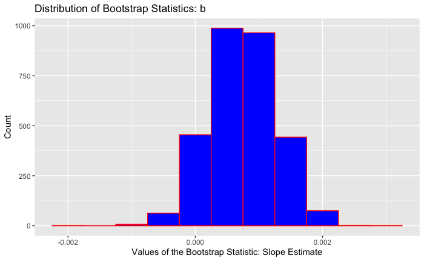

```r
bootstrapresultsdf %>%
  ggplot(aes(x = b.boot)) +
  geom_histogram(col = "red", fill = "blue", binwidth = 0.0005) +
  xlab("Values of the Bootstrap Statistic: Slope Estimate") +
  ylab("Count") +
  ggtitle("Distribution of Bootstrap Statistics: b")
```

```r
favstats(~b.boot, data = bootstrapresultsdf)
```

|  | min | Q1 | median | Q3 | max | mean | sd | n | missing |
| --- | --- | --- | --- | --- | --- | --- | --- | --- | --- |
|  | -0.001798351 | 0.0003915403 | 0.0007457782 | 0.00111571 | 0.002771317 | 0.0007526138 | 0.0005191014 | 3000 | 0 |

```r
qdata(~b.boot, c(0.025, 0.975), data = bootstrapresultsdf)
```

|  | quantile | p |
| --- | --- | --- |
| 2.5% | -0.0002368665 | 0.025 |
| 97.5% | 0.0017537055 | 0.975 |

The bootstrap distribution of the *mean of* of $y$ for $X = 60000$ is provided below

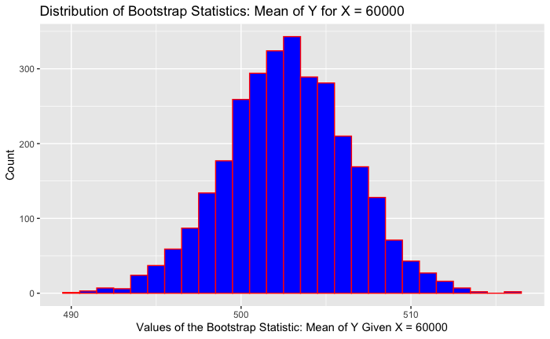

```r
bootstrapresultsdf %>%
  ggplot(aes(x = ymean.boot)) +
  geom_histogram(col = "red", fill = "blue", binwidth = 1) +
  xlab("Values of the Bootstrap Statistic: Mean of Y Given X = 60000") +
  ylab("Count") +
  ggtitle("Distribution of Bootstrap Statistics: Mean of Y for X = 60000")
```

```r
favstats(~ymean.boot, data = bootstrapresultsdf)
```

|  | min | Q1 | median | Q3 | max | mean | sd | n | missing |
| --- | --- | --- | --- | --- | --- | --- | --- | --- | --- |
|  | 490.3074 | 500.3785 | 502.7686 | 505.2198 | 516.1247 | 502.7707 | 3.656992 | 3000 | 0 |

```r
qdata(~ymean.boot, c(0.025, 0.975), data = bootstrapresultsdf)
```

|  | quantile | p |
| --- | --- | --- |
| 2.5% | 495.4092 | 0.025 |
| 97.5% | 509.9086 | 0.975 |

```r
predict(predictmathSAT, newdata = data.frame(salary = 60000), interval = "conf", conf.level = 0.95)
```

```
       fit      lwr      upr
1 502.5898 494.3102 510.8693
```

$$494.3102 \leq \mu_{y|x=6000} \leq 510.8693$$

Both results are very close.

**Time to Play Around:**

As an extension to the problem at hand of prediction the home attendance (in millions) - **seasonattend** - of an American League baseball team from its season winninng percentage (**winningpct**), create the distribution for each of the following bootstrap statistics:

```r
MLBattend <- read.csv("http://people.ucalgary.ca/~jbstall/DataFiles/baseball.csv")
MLBattend <- MLBattend %>%
  mutate(winningpct = c(wins / (wins + losses)))
MLBattend = MLBattend %>%
  mutate(seasonattend = (attendance/1000000))
predictattendanceAL = lm(seasonattend~winningpct, data = filter(MLBattend, league == "AL"))
```

```r
Nbootstraps_ttp = 3000 #resample n =  14, 3000 times
cor.boot_ttp = numeric(Nbootstraps_ttp) #define a vector to be filled by the cor boot stat
a.boot_ttp = numeric(Nbootstraps_ttp) #define a vector to be filled by the a boot stat
b.boot_ttp = numeric(Nbootstraps_ttp) #define a vector to be filled by the b boot stat
ymean.boot_ttp = numeric(Nbootstraps_ttp) #define a vector to be filled by the predicted y boot stat
```

The above chunk is ran before we go any further, as we are setting up some “global” parameters for the code.